# 一、项目背景与流程目标

# 五、 RFM模型重构

RFM-I 模型的核心构建函数，核心逻辑是先对经典 RFM 指标（最近活跃度、购买频率、消费金额）做归一化，再结合意向深度（I_Score）计算最终的综合得分（Final_Score），为后续用户分群和业务策略落地提供量化依据。

```python
def build_rfm_model(df):
    """构建RFM-I模型：标准化、综合得分计算"""

    # 归一化函数
    def min_max_normalize(series, reverse=False):
        min_val, max_val = series.min(), series.max()
        if max_val == min_val:
            return pd.Series([50] * len(series))
        if reverse:
            return ((max_val - series) / (max_val - min_val)) * 100
        return ((series - min_val) / (max_val - min_val)) * 100

    df['R_Score'] = min_max_normalize(df['Last_Login_Days_Ago'], reverse=True)
    df['F_Score'] = min_max_normalize(df['Purchase_Frequency'])
    df['M_Score'] = min_max_normalize(df['Total_Spending'])
    df['RFM_Score'] = 0.2 * df['R_Score'] + 0.3 * df['F_Score'] + 0.5 * df['M_Score']
    df['I_Weight'] = df['I_Score'] / 500  # I_Score 0-100 -> 0-0.2
    df['Final_Score'] = df['RFM_Score'] * (1 + df['I_Weight'])

    print(f"R_Score 范围: [{df['R_Score'].min():.2f}, {df['R_Score'].max():.2f}]")
    print(f"F_Score 范围: [{df['F_Score'].min():.2f}, {df['F_Score'].max():.2f}]")
    print(f"M_Score 范围: [{df['M_Score'].min():.2f}, {df['M_Score'].max():.2f}]")
    print(f"RFM_Score 范围: [{df['RFM_Score'].min():.2f}, {df['RFM_Score'].max():.2f}]")
    print(f"Final_Score 范围: [{df['Final_Score'].min():.2f}, {df['Final_Score'].max():.2f}]")

    return df

df = build_rfm_model(df)
df[['User_ID','R_Score','F_Score','M_Score','I_Score','RFM_Score','Final_Score']].head()
```

```
R_Score 范围: [0.00, 100.00]
F_Score 范围: [0.00, 100.00]
M_Score 范围: [0.00, 100.00]
RFM_Score 范围: [4.72, 96.77]
Final_Score 范围: [5.26, 105.06]
```

|  | User_ID | R_Score | F_Score | M_Score | I_Score | RFM_Score | Final_Score |
| --- | --- | --- | --- | --- | --- | --- | --- |
| 0 | #1 | 85.714286 | 77.777778 | 49.805607 | 87.285385 | 65.378994 | 76.792255 |
| 1 | #2 | 50.000000 | 77.777778 | 4.256190 | 76.638400 | 35.461428 | 40.896843 |
| 2 | #3 | 3.571429 | 11.111111 | 74.769797 | 25.460637 | 41.432518 | 43.542314 |
| 3 | #4 | 39.285714 | 33.333333 | 87.272355 | 73.136516 | 61.493320 | 70.488135 |
| 4 | #5 | 96.428571 | 55.555556 | 89.830162 | 13.646357 | 80.867462 | 83.074554 |

# 六、 用户分层与画像

RFM-I 模型落地的核心环节—— 基于 RFM 得分、意向分、收入等级等多维度特征，将用户划分成有业务语义的分层标签（比如 “核心 VIP”“高潜沉睡用户”），并生成各分层的量化画像，让技术指标转化为业务可直接使用的用户分类。

```python
# 7. 用户分层与画像
def classify_users(df):
    """用户分层：基于RFM-I模型进行精细化分层"""


    def classify_user(row):
        r = row['R_Score']
        f = row['F_Score']
        m = row['M_Score']
        i = row['I_Score']
        income = row['Income_Level']
        friction = row['Friction']
        l = row['L_Score']

        # 基础RFM分层逻辑
        if r > 60 and f > 60 and m > 60:
            base_label = "重要价值用户"
        elif r > 60 and m > 60 and f < 40:
            base_label = "重要发展用户"
        elif r < 40 and f > 60 and m > 60:
            base_label = "重要保持用户"
        elif r < 40 and m > 60:
            base_label = "重要挽留用户"
        elif r > 60 and f > 40 and m < 40:
            base_label = "一般发展用户"
        elif r > 60 and f < 40 and m < 40:
            base_label = "一般维持用户"
        elif r < 40 and f < 40 and m < 40:
            base_label = "低价值用户"
        else:
            base_label = "一般用户"

        # 关键修正逻辑
        #收入高且意向度高但rfm得分低
        if base_label in ["低价值用户", "一般维持用户"] and income == "High" and i > 60:
            return "高潜沉睡用户"

        #收入高且意向度高但消费少
        if income == "High" and i > 70 and f < 40 and m < 50:
            return "纠结土豪"

        #意向度和摩擦系数较高
        if base_label in ["一般维持用户", "一般发展用户"] and i > 80 and friction > df['Friction'].quantile(0.6):
            return "犹豫型潜力用户"

        #收入和购买频次低但意向度高
        if income == "Low" and i > 70 and f < 40:
            return "隐形活跃者"

        #收入高买的少
        if income == "High" and r < 40 and m > 50:
            return "高潜流失客"

        #消费大 买的多 意向高
        if m > 70 and f > 70 and i > 60:
            return "核心VIP"

        #收入低 买的少
        if income == "Low" and i < 40 and m < 40:
            return "羊毛党/低值"

        return base_label

    df['User_Segment'] = df.apply(classify_user, axis=1)

    # 分层统计
    segment_stats = df.groupby('User_Segment').agg({
        'User_ID': 'count',
        'Total_Spending': 'mean',
        'Purchase_Frequency': 'mean',
        'I_Score': 'mean',
        'Income': 'mean',
        'Final_Score': 'mean'
    }).round(2)

    #用数据量化每个分层的核心特征
    segment_stats.columns = ['用户数', '平均消费', '平均购买频率', '平均意向分', '平均收入', '平均综合分']
    segment_stats['占比(%)'] = (segment_stats['用户数'] / len(df) * 100).round(1)
    segment_stats = segment_stats.sort_values('用户数', ascending=False)

    print("\n用户分层统计:")
    print(segment_stats.to_string())

    return df, segment_stats

df, segment_stats = classify_users(df)
```

```
用户分层统计:
              用户数     平均消费  平均购买频率  平均意向分       平均收入  平均综合分  占比(%)
User_Segment
一般用户          443  2368.12    5.17  48.80   84305.72  54.31   44.3
一般发展用户         81  1117.95    6.43  49.84   87107.43  52.67    8.1
重要挽留用户         67  4134.42    2.57  46.53   59698.61  58.59    6.7
高潜流失客          64  3990.70    4.92  44.09  121985.09  65.40    6.4
低价值用户          50  1036.52    1.68  42.79   94734.76  20.87    5.0
重要发展用户         48  3873.96    1.62  48.91   81230.60  65.41    4.8
一般维持用户         47  1055.40    1.47  45.83   91335.23  33.57    4.7
重要价值用户         47  3960.19    7.47  42.28   73500.94  86.82    4.7
重要保持用户         39  4030.23    7.49  48.00   57995.92  75.26    3.9
隐形活跃者          34  2756.79    1.32  77.99   36273.32  47.28    3.4
羊毛党/低值         32  1019.56    5.50  23.08   37896.19  37.05    3.2
核心VIP          23  4171.39    8.17  71.09   59382.39  88.86    2.3
高潜沉睡用户         12  1318.17    1.75  74.34  121952.83  35.20    1.2
犹豫型潜力用户         7   738.86    2.43  90.23   60211.71  34.69    0.7
纠结土豪            6  1156.67    1.67  78.86  125519.00  30.24    0.6
```

# 七、用户画像可视化

通过「雷达图」直观对比不同用户分层的 R/F/M/I 核心特征，通过「柱状图」展示各分层的用户数量分布，把抽象的分层数据转化为业务人员能快速理解的可视化图表。

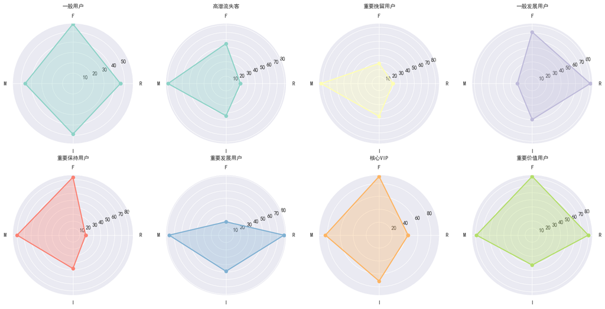

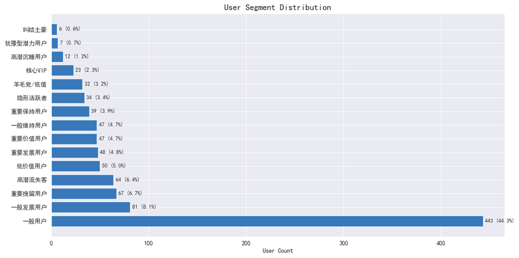

```python
def generate_segment_portrait(df, output_dir):
    """生成用户画像可视化：雷达图和分布柱状图"""

    # 分层雷达图
    segments = df['User_Segment'].unique()#获取所有用户分层标签（比如核心VIP、高潜沉睡用户）
    metrics = ['R_Score', 'F_Score', 'M_Score', 'I_Score'] # 雷达图要展示的4个核心指标

     # 计算每个分层的4个指标平均值（用于雷达图绘制）
    segment_means = df.groupby('User_Segment')[metrics].mean()

    # 2. 创建画布：2行4列的极坐标子图（最多展示8个分层，避免图表拥挤）
    fig, axes = plt.subplots(2, 4, figsize=(16, 8), subplot_kw=dict(polar=True))
    axes = axes.flatten()# 将2×4的二维数组转为一维，方便循环遍历

    # 3. 计算雷达图的角度（4个指标对应4个角度，闭合雷达图）
    angles = np.linspace(0, 2 * np.pi, len(metrics), endpoint=False).tolist()
    angles += angles[:1]# 最后添加第一个角度，让雷达图闭合（比如[0, π/2, π, 3π/2] → [0, π/2, π, 3π/2, 0]）

    # 4. 生成差异化颜色（每个分层对应不同颜色，提升辨识度
    colors = plt.cm.Set3(np.linspace(0, 1, len(segments)))

     # 5. 循环绘制每个分层的雷达图（最多画8个）
    for idx, segment in enumerate(segments[:8]):
        if idx >= len(axes):
            break
        ax = axes[idx]

         # 提取当前分层的4个指标均值，闭合数据（和角度对应）
        values = segment_means.loc[segment].tolist()
        values += values[:1]

        # 绘制雷达图：填充区域（透明）+ 轮廓线（清晰）
        ax.fill(angles, values, alpha=0.3, color=colors[idx])
        ax.plot(angles, values, 'o-', color=colors[idx], linewidth=2)

        # 设置雷达图的刻度标签（简化为R/F/M/I，提升可读性）
        ax.set_xticks(angles[:-1])
        ax.set_xticklabels(['R', 'F', 'M', 'I'], fontsize=10)
        ax.set_title(segment, fontsize=10, pad=10)

     # 6. 隐藏未使用的子图（如果分层数<8，把多余的子图隐藏）
    for idx in range(len(segments), len(axes)):
        axes[idx].set_visible(False)

     # 7. 保存并展示雷达图
    plt.tight_layout()
    plt.savefig(f'{output_dir}/segment_radar.png', dpi=150, bbox_inches='tight')
    plt.show()
    plt.close()

    # 分层分布柱状图
    segment_counts = df['User_Segment'].value_counts()

    fig, ax = plt.subplots(figsize=(12, 6))
    bars = ax.barh(segment_counts.index, segment_counts.values, color='#0B5CAD', alpha=0.8)
    ax.set_xlabel('User Count')
    ax.set_title('User Segment Distribution', fontsize=14)

    for bar, count in zip(bars, segment_counts.values):
        ax.text(bar.get_width() + 2, bar.get_y() + bar.get_height()/2,
                f'{count} ({count/len(df)*100:.1f}%)', va='center', fontsize=9)

    plt.tight_layout()
    plt.savefig(f'{output_dir}/segment_distribution.png', dpi=150, bbox_inches='tight')
    plt.show()
    plt.close()

generate_segment_portrait(df, output_dir)
```

# 八、ROI测算

通过「边际收益法」对比 “传统 RFM 策略” 和 “优化 RFI 策略” 的 ROI（投资回报率），量化证明精细化分层策略的商业价值，同时提供可调整的参数和可视化对比，让 ROI 测算结果可落地、可校准。

```
============================================================
第六阶段：ROI测算
============================================================

【假设参数】
  总预算: 10000元
  优惠券成本: 10元/人
  平均客单价: 104元

【转化率假设】
  RFM前20%用户：自然转化率 20.0%，发券后 30.0%，边际提升 10.0%
  核心用户：自然转化率 25.0%，发券后 30.0%，边际提升 5.0%
  潜力用户：自然转化率 1.0%，发券后 20.0%，边际提升 19.0%

【方案A - 传统RFM策略】
  目标用户数: 200
  成本: 2000元
  边际收益（增量）: 2081元
  边际ROI: 4.0%

【方案B - 优化RFI策略】
  核心用户: 70
  新挖掘潜力用户: 89
  总目标用户数: 159
  实际成本: 1590元 (预算使用率: 15.9%)
  边际收益（增量）: 2123元
  边际ROI: 33.5%
```

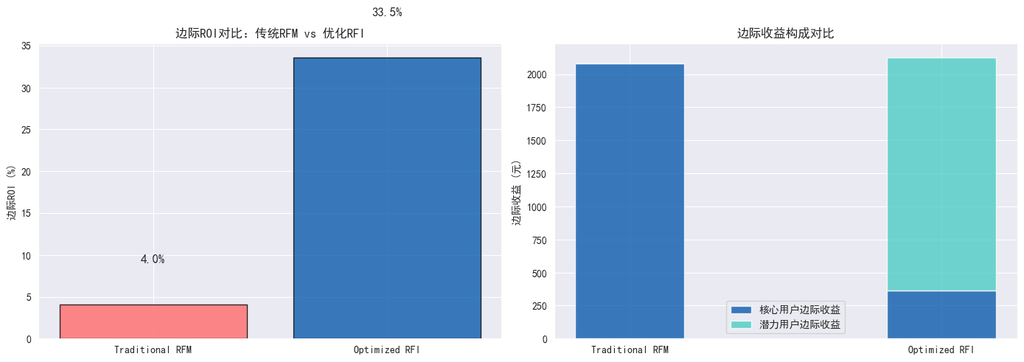

```python
# 9. ROI测算
def calculate_roi(df, output_dir):
    """ROI测算：传统RFM vs 优化RFI策略对比（边际收益法，参数可调）"""

    print("\n" + "=" * 60)
    print("第六阶段：ROI测算")
    print("=" * 60)

    # ================= 可调整参数=================
    total_budget = 10000          # 总预算（元）
    coupon_cost = 10               # 每张优惠券成本（元）
    aov = df['Average_Order_Value'].mean()  # 平均客单价（元）

    # 转化率假设（可根据历史数据校准）
    # 核心用户
    core_natural = 0.25            # 核心用户无券自然转化率
    core_with_coupon = 0.30        # 核心用户发券后转化率
    # 潜力用户
    potential_natural = 0.01       # 潜力用户自然转化率
    potential_with_coupon = 0.20   # 潜力用户发券后转化率（可调高至20%-25%）
    # 一般用户（用于方案A的基线）
    general_natural = 0.02          # 一般用户自然转化率
    # RFM前20%用户的自然转化率（介于核心和一般之间）
    rfm20_natural = 0.20            # 可根据实际数据调整，例如：RFM高分用户通常转化率较高
    rfm20_with_coupon = 0.30        # 发券后转化率（通常不会超过核心用户）

    # 边际提升
    core_lift = core_with_coupon - core_natural
    potential_lift = potential_with_coupon - potential_natural
    rfm20_lift = rfm20_with_coupon - rfm20_natural

    # ================= 方案A：传统RFM策略 =================
    top20_threshold = df['RFM_Score'].quantile(0.80)
    rfm_top20 = df[df['RFM_Score'] >= top20_threshold]
    target_a_count = min(len(rfm_top20), total_budget // coupon_cost)
    cost_a = target_a_count * coupon_cost

    incremental_revenue_a = target_a_count * rfm20_lift * aov
    roi_a = (incremental_revenue_a - cost_a) / cost_a * 100 if cost_a > 0 else 0

    # ================= 方案B：优化RFI策略 =================
    core_users = df[df['User_Segment'].isin(['核心VIP', '重要价值用户'])]
    potential_users = df[df['User_Segment'].isin(['纠结土豪', '高潜沉睡用户', '犹豫型潜力用户', '高潜流失客'])]

    # 分配预算：优先核心用户（用80%预算），剩余给潜力用户
    core_count = min(len(core_users), int(total_budget * 0.8 / coupon_cost))
    remaining_budget = total_budget - core_count * coupon_cost
    potential_count = min(len(potential_users), remaining_budget // coupon_cost)
    target_b_count = core_count + potential_count
    cost_b = target_b_count * coupon_cost

    incremental_revenue_b = core_count * core_lift * aov + potential_count * potential_lift * aov
    roi_b = (incremental_revenue_b - cost_b) / cost_b * 100 if cost_b > 0 else 0

    # ================= 输出结果 =================
    print(f"\n【假设参数】")
    print(f"  总预算: {total_budget}元")
    print(f"  优惠券成本: {coupon_cost}元/人")
    print(f"  平均客单价: {aov:.0f}元")

    print(f"\n【转化率假设】")
    print(f"  RFM前20%用户：自然转化率 {rfm20_natural*100:.1f}%，发券后 {rfm20_with_coupon*100:.1f}%，边际提升 {rfm20_lift*100:.1f}%")
    print(f"  核心用户：自然转化率 {core_natural*100:.1f}%，发券后 {core_with_coupon*100:.1f}%，边际提升 {core_lift*100:.1f}%")
    print(f"  潜力用户：自然转化率 {potential_natural*100:.1f}%，发券后 {potential_with_coupon*100:.1f}%，边际提升 {potential_lift*100:.1f}%")

    print(f"\n【方案A - 传统RFM策略】")
    print(f"  目标用户数: {target_a_count}")
    print(f"  成本: {cost_a}元")
    print(f"  边际收益（增量）: {incremental_revenue_a:.0f}元")
    print(f"  边际ROI: {roi_a:.1f}%")

    print(f"\n【方案B - 优化RFI策略】")
    print(f"  核心用户: {core_count}")
    print(f"  新挖掘潜力用户: {potential_count}")
    print(f"  总目标用户数: {target_b_count}")
    print(f"  实际成本: {cost_b}元 (预算使用率: {cost_b/total_budget*100:.1f}%)")
    print(f"  边际收益（增量）: {incremental_revenue_b:.0f}元")
    print(f"  边际ROI: {roi_b:.1f}%")

    # ROI对比可视化
    fig, axes = plt.subplots(1, 2, figsize=(14, 5))

    # 边际ROI对比
    strategies = ['Traditional RFM', 'Optimized RFI']
    rois = [roi_a, roi_b]
    colors = ['#FF6B6B', '#0B5CAD']

    bars = axes[0].bar(strategies, rois, color=colors, alpha=0.8, edgecolor='black')
    axes[0].set_ylabel('边际ROI (%)')
    axes[0].set_title('边际ROI对比：传统RFM vs 优化RFI', fontsize=12)
    for bar, roi in zip(bars, rois):
        axes[0].text(bar.get_x() + bar.get_width()/2, bar.get_height() + 5,
                    f'{roi:.1f}%', ha='center', fontsize=12, fontweight='bold')

    # 边际收益构成对比
    x = np.arange(2)
    width = 0.35

    core_marginal = [incremental_revenue_a, core_count * core_lift * aov]
    potential_marginal = [0, potential_count * potential_lift * aov]

    axes[1].bar(x, core_marginal, width, label='核心用户边际收益', color='#0B5CAD', alpha=0.8)
    axes[1].bar(x, potential_marginal, width, bottom=core_marginal, label='潜力用户边际收益', color='#4ECDC4', alpha=0.8)
    axes[1].set_xticks(x)
    axes[1].set_xticklabels(strategies)
    axes[1].set_ylabel('边际收益 (元)')
    axes[1].set_title('边际收益构成对比', fontsize=12)
    axes[1].legend()

    plt.tight_layout()
    plt.savefig(f'{output_dir}/roi_comparison.png', dpi=150, bbox_inches='tight')
    plt.show()
    plt.close()

    return {
        'strategy_a': {
            'target_count': int(target_a_count),
            'cost': cost_a,
            'incremental_revenue': incremental_revenue_a,
            'marginal_roi': roi_a
        },
        'strategy_b': {
            'core_count': int(core_count),
            'potential_count': int(potential_count),
            'total_count': int(target_b_count),
            'actual_cost': cost_b,
            'budget_used_ratio': cost_b/total_budget,
            'incremental_revenue': incremental_revenue_b,
            'marginal_roi': roi_b
        },
        'params': {
            'budget': total_budget,
            'coupon_cost': coupon_cost,
            'aov': aov,
            'rfm20_lift': rfm20_lift,
            'core_lift': core_lift,
            'potential_lift': potential_lift
        }
    }
roi_results = calculate_roi(df, output_dir)
```